# Surface Area Analysis

Ian Combs – icombs@mote.org

### version: November 08, 2022

#### [GitHub repository](https://github.com/icombs2017/fragGrowthExperiment.git)

This is the working analysis pipeline to analyze data generated from 3D models of micro-fragmented coral colonies and larger frags to assess differences in growth rates between microfragments and natural growth.

### All analyses performed with R version 4.2.1

# Basic setup of R environment

## Loading required packages

For the following analyses we will require the use of a number of different R packages. Most of which can be sourced from CRAN, but some must be downloaded from GitHub. We can use the following code to load in the packages and install any packages not previously installed in the R console.

```r
if (!require("pacman")) install.packages("pacman")
pacman::p_load("ggplot2", "googlesheets4", "dplyr", "officer","reshape2", "stringr", "flextable", "gridExtra", "ggpubr", "Rmisc", "rcompanion", "RColorBrewer", "googledrive", "gdata", "readxl", "DescTools","patchwork", "FSA", "rstatix", "tidyverse", "lme4", 'PMCRMplus', "EnvStats", "emmeans", "MuMIn", "sjstats", "lmerTest")
```

# Importing Data

## We are downloading this dataset from our GoogleDrive folder. We will be using the package `googledrive`. Each GoogleDrive file has a unique ID that does not change throughout the lifespan of the document, even if the file name is changed. This ID is housed in the file’s URL.

Example: docs.google.com/spreadsheets/d/FILE_ID_GOES_HERE/other_information/. Below you will copy and paste that into the function `drive_download` within `as_id`. This will save the file locally in the specified path (in this case our data folder) and you will import the folder as you normally would. Downloading it this way decreases the potential human error when downloading, moving folders, renaming, saving etc and ensures that the most up to date file is being utilized.

# Here we are loading the whole data set from the Google Drive

```r
# drive_download(
#   as_id("1C1deEPnb07YcvbEngx_OV3Xl-C740sBefoaum154OyY"),
#   path = "../data/saDatasetTotal.xlsx",
#   overwrite = TRUE)

total <- read_excel("../data/saDatasetTotal.xlsx", sheet = 1)

total
```

```
## # A tibble: 132 × 15
##    timePoint species genot…¹ id    trial treat…² scale…³ scale…⁴ scale…⁵ average scale…⁶
##    <chr>     <chr>     <dbl> <chr> <dbl> <chr>     <dbl>   <dbl>   <dbl>   <dbl>   <dbl>
##  1 initial   DL            1 DL1       1 wild      1.27    1.18    1.21    1.22     1.64
##  2 initial   PC           16 PC16      1 wild      0.227   0.227   0.237   0.230    8.68
##  3 initial   PS           13 PS13      1 wild      1.87    1.86    1.84    1.86     1.08
##  4 initial   PS           14 PS14      1 wild      1.77    1.82    1.77    1.79     1.12
##  5 initial   DL            1 DL1       1 frag      2.02    1.93    2.00    1.98     1.01
##  6 initial   DL            2 DL2       1 frag      1.19    1.21    1.21    1.20     1.66
##  7 initial   DL            3 DL3       1 frag      0.707   0.709   0.712   0.709    2.82
##  8 initial   PC           13 PC13      1 frag      1.44    1.43    1.46    1.44     1.38
##  9 initial   PC           15 PC15      1 frag      1.01    0.987   1.01    1.00     1.99
## 10 initial   PC           16 PC16      1 frag      1.05    1.00    1.00    1.02     1.96
## # … with 122 more rows, 4 more variables: `surfaceArea (cm^2)` <dbl>, ryanSA <dbl>,
## #   notes <chr>, `t6-t0` <dbl>, and abbreviated variable names ¹genotype, ²treatment,
## #   ³`scale 1`, ⁴`scale 2`, ⁵`scale 3`, ⁶scaleFactor
```

## Now I am just tidying up my dataset, I am combining two columns, **species** and **genotype** into a column **geno** using the `paste0` function, cleaning up the raw dataset to only include my species of concern using multiple functions from the package `dplyr`, and changing the class of some variables to factors using the function `as.factor()` for easier manipulation down the road.

```r
totalClean <- total %>%
  select("timePoint", "species", "id","trial","treatment","surfaceArea (cm^2)") %>%
  filter(species %in% c("DL", "PC", "PS")) %>%
  filter(timePoint %in% c("initial", "T3", "T6")) %>%
  dplyr::rename("SA" = "surfaceArea (cm^2)")


  totalClean$timePoint <- gsub("initial", "T0", totalClean$timePoint)


totalClean$timepoint <- as.factor(totalClean$timePoint)

totalClean$species <- as.factor(totalClean$species)

totalClean$id <- as.factor(totalClean$id)

totalClean$trial <- as.factor(totalClean$trial)

totalClean$treatment <- as.factor(totalClean$treatment)
```

```r
totalFrag <- totalClean %>%
  select(timepoint, species, id, treatment, SA) %>%
  dplyr::filter(treatment %in% 'frag') %>%
  dplyr::group_by(timepoint, species, id, treatment) %>%
  dplyr::summarise(sum(SA)) %>%
  dplyr::rename("SA" = "sum(SA)")
totalWild <- totalClean %>%
  dplyr::filter(treatment %in% 'wild') %>%
  select(timepoint, species, id, treatment, SA)

totalCombo <- bind_rows(totalFrag,totalWild)

totalFinal <- totalCombo %>%
  dplyr::filter(timepoint %in% c("T0","T3","T6")) %>%
  select(c('timepoint','species','id','treatment', "SA"))



totalChange <- dcast(totalFinal, id+species+treatment~timepoint)
totalChange$`T3-T0` <- ((totalChange$T3-totalChange$T0)/totalChange$T0)*100
totalChange$`T6-T3` <- ((totalChange$T6 -totalChange$T3)/totalChange$T3)*100
totalChange$`T6-T0` <- ((totalChange$T6-totalChange$T0)/totalChange$T0)*100

totalChange <- totalChange %>%
  select("id", "species","treatment", "T3-T0","T6-T3")

totalChangeMelt <- melt(totalChange, id = c(1,2,3))

totalChangeMelt <- totalChangeMelt %>%
  dplyr::rename("timeSeries" = "variable") %>%
  dplyr::rename("percentChange" = "value")
totalChange <- totalChangeMelt

totalChange$timeSeries <- as.factor(totalChange$timeSeries)
```

#Here we are creating percent change figures for dl, pc, and ps using ‘ggplot’

```r
# dlSApercentChange.1 <- ggplot(data=dlsaChange, aes(x=id, y=percentChange, fill=treatment)) +
#     geom_bar(colour="black", stat="identity",
#              position=position_dodge(),
#              size=.3) +  scale_fill_manual(name="Treatment",labels=c('Frag', 'Wild'),values = c("#0EBEBE","#9FA0FF")) +
#     xlab("ID") + ylab("Percent Change (%)") +
#     ggtitle("D. lab") +
#     theme_bw()
#
#
# dlSApercentChange <- dlSApercentChange.1 + theme(
#   panel.grid.major = element_line(size = 0.5, linetype = 'solid', colour = "white"),
#   panel.background = element_rect(fill = '#F5F5F5'),
#   plot.title = element_text(hjust = 0.5),
#   axis.line = element_line(colour = "black"),
#   axis.ticks = element_line(color="black"),
#   text = element_text(size = 22, color="black"),
#   axis.text.x=element_text(size = 18, color="black"),
#   axis.text.y=element_text(size = 18, color="black"),
#   legend.position = "right")
#
# dlSApercentChange.1
#
# ggsave("../figures/dlPercentSAgrowth.png", plot = dlSApercentChange, height = 5, width = 9, units = 'in',dpi = 600)
#
```

```r
# pcSApercentChange.1 <- ggplot(data=pcsaChange, aes(x=id, y=percentChange, fill=treatment)) +
#     geom_bar(colour="black", stat="identity",
#              position=position_dodge(),
#              size=.3) + scale_fill_manual(name="Treatment",labels=c('Frag', 'Wild'),values = c("#0EBEBE","#9FA0FF")) +
#     xlab("ID") + ylab("Percent Change (%)") + # Set axis labels
#     ggtitle("P. cli") +     # Set title
#     theme_bw()
#
# pcSApercentChange <- pcSApercentChange.1 + theme(
#   panel.grid.major = element_line(size = 0.5, linetype = 'solid', colour = "white"),
#   panel.background = element_rect(fill = '#F5F5F5'),
#   plot.title = element_text(hjust = 0.5),
#   axis.line = element_line(colour = "black"),
#   axis.ticks = element_line(color="black"),
#   text = element_text(size = 22, color="black"),
#   axis.text.x=element_text(size = 18, color="black"),
#   axis.text.y=element_text(size = 18, color="black"),
#   legend.position = "right")
#
# pcSApercentChange
#
# ggsave("../figures/pcPercentSAgrowth.png", plot = pcSApercentChange, height = 5, width = 9, units = 'in',dpi = 600)
#
```

```r
# psSApercentChange.1 <- ggplot(data=pssaChange, aes(x=id, y=percentChange, fill=treatment)) +
#     geom_bar(colour="black", stat="identity",
#              position=position_dodge(),
#              size=.3) +scale_fill_manual(name="Treatment",labels=c('Frag', 'Wild'),values = c("#0EBEBE","#9FA0FF"))+
#     xlab("ID") + ylab("Percent Change (%)") +
#     ggtitle("P. str") +
#     theme_bw()
#
# psSApercentChange <- psSApercentChange.1 + theme(
#   panel.grid.major = element_line(size = 0.5, linetype = 'solid', colour = "white"),
#   panel.background = element_rect(fill = '#F5F5F5'),
#   plot.title = element_text(hjust = 0.5),
#   axis.line = element_line(colour = "black"),
#   axis.ticks = element_line(color="black"),
#   text = element_text(size = 22, color="black"),
#   axis.text.x=element_text(size = 18, color="black"),
#   axis.text.y=element_text(size = 18, color="black"),
#   legend.position = "right")
#
# psSApercentChange
#
# ggsave("../figures/psPercentSAgrowth.png", plot = psSApercentChange, height = 5, width = 9, units = 'in',dpi = 600)
```

#Here we are creating a change in surface area figure for dl, pc, and ps using ‘ggplot’

```r
# dlSAgrowthGenotype.1 <- ggplot(data=dlsaFinal, aes(x = treatment, y = SA, fill = timepoint)) +
#   geom_bar(stat = "identity", position = position_dodge())+
#   facet_wrap(~id)+
#   scale_fill_hue(name="Time Point") +
#   labs(x = "Treatment", y = bquote("Surface Area" ~ (cm^2)),fill='Time Point') +
#     ggtitle("Surface Area Growth of DL01, DL02, and DL03") + scale_fill_discrete(labels=c('Initial','T3','Final'))+scale_x_discrete(labels=c("frag" = "Frag", "wild" = "Wild"))+scale_fill_manual(values = c("#0053A6", "#D3F292", "#5CADFF"))
#
# dlSAgrowthGenotype.1
#
# dlSAgrowthGenotype <- dlSAgrowthGenotype.1 + theme(
#   panel.grid.major = element_line(size = 0.5, linetype = 'solid', colour = "white"),
#   panel.background = element_rect(fill = '#F5F5F5'),
#   plot.title = element_text(hjust = 0.5),
#   axis.line = element_line(colour = "black"),
#   axis.ticks = element_line(color="black"),
#   text = element_text(size = 22, color="black"),
#   axis.text.x=element_text(size = 18, color="black"),
#   axis.text.y=element_text(size = 18, color="black"),
#   legend.position = "right")
#
#
# dlSAgrowthGenotype
#
# ggsave("../figures/dlSAgrowth.png", plot = dlSAgrowthGenotype, height = 5, width = 9, units = 'in',dpi = 600)
```

```r
# pcSAgrowthGenotype.1 <- ggplot(data=pcsaFinal, aes(x = treatment, y = SA, fill = timepoint)) +
#   geom_bar(stat = "identity", position = position_dodge())+
#   facet_wrap(~id)+
#   scale_fill_hue(name="Time Point") +
#   labs(x = "Treatment", y = bquote("Surface Area" ~ (cm^2)),fill='Time Point') +
#     ggtitle("Surface Area Growth of PC13, PC15, and PC16") + scale_fill_discrete(labels=c('Initial','T3','Final'))+scale_x_discrete(labels=c("frag" = "Frag", "wild" = "Wild"))+scale_fill_manual(values = c("#0053A6", "#D3F292", "#5CADFF"))
#
# pcSAgrowthGenotype.1
#
# pcSAgrowthGenotype <- pcSAgrowthGenotype.1 + theme(
#   panel.grid.major = element_line(size = 0.5, linetype = 'solid', colour = "white"),
#   panel.background = element_rect(fill = '#F5F5F5'),
#   plot.title = element_text(hjust = 0.5),
#   axis.line = element_line(colour = "black"),
#   axis.ticks = element_line(color="black"),
#   text = element_text(size = 22, color="black"),
#   axis.text.x=element_text(size = 18, color="black"),
#   axis.text.y=element_text(size = 18, color="black"),
#   legend.position = "right")
#
#
# pcSAgrowthGenotype
#
# ggsave("../figures/pcSAgrowth.png", plot = pcSAgrowthGenotype, height = 5, width = 9, units = 'in',dpi = 600)
#
```

````r
# psSAgrowthGenotype.1 <- ggplot(data=pssaFinal, aes(x = treatment, y = SA, fill = timepoint)) +
#   geom_bar(stat = "identity", position = position_dodge())+
#   facet_wrap(~id)+
#   scale_fill_hue(name="Time Point") +
#   labs(x = "Treatment", y = bquote("Surface Area" ~ (cm^2)),fill='Time Point') +
#     ggtitle("Surface Area Growth of PS07, PS11, PS12, PS13, and PS14") + scale_fill_discrete(labels=c('Initial','T3','Final'))+scale_x_discrete(labels=c("frag" = "Frag", "wild" = "Wild"))+scale_fill_manual(values = c("#0053A6", "#D3F292", "#5CADFF"))
#
# psSAgrowthGenotype.1
#
# psSAgrowthGenotype <- psSAgrowthGenotype.1 + theme(
#   panel.grid.major = element_line(size = 0.5, linetype = 'solid', colour = "white"),
#   panel.background = element_rect(fill = '#F5F5F5'),
#   plot.title = element_text(hjust = 0.5),
#   axis.line = element_line(colour = "black"),
#   axis.ticks = element_line(color="black"),
#   text = element_text(size = 22, color="black"),
#   axis.text.x=element_text(size = 18, color="black"),
#   axis.text.y=element_text(size = 18, color="black"),
#   legend.position = "right")
#
#
# psSAgrowthGenotype
#
# ggsave("../figures/psSAgrowth.png", plot = psSAgrowthGenotype, height = 10, width = 15, units = 'in',dpi = 600)


#
# ```
#
# #Here we are combining all of the surface area percent change figures (grouped by species)
#
# ```{r, combinedSApercentChangeVisualization , include = TRUE}
# library(ggplot2)
# library(ggpubr)
# theme_set(theme_pubr())
#
# percentChange <- ggarrange(dlSApercentChange, pcSApercentChange, psSApercentChange,
#                     labels = c("A", "B", "C"),
#                     ncol = 2, nrow = 2, common.legend = TRUE, legend = "right")
# percentChange <- annotate_figure(
#   percentChange,
#   top = text_grob("Surface Area Percent Change",
#                   color = "black", face = "bold", size = 24))
#
#
# percentChange
#
# ggsave("../figures/percentChange.png", plot = percentChange, height = 15, width = 20, units = 'in',dpi = 600)
#
# ```
#
# #Now we will run a paired t-test to determine if the percent change in surface area of the frags varies from the wilds. First, we need to assess normality via the shapiro-wilk test for normal distribution and the Levene's Test to test for homogeneity of variance. If neither is significant, we will conduct a t-test.
#
# ```{r,dlPercentChangeTest,include = TRUE}
# dlsaFragTest <- dlsaChange %>%
#   select(id, treatment, percentChange) %>%
#   dplyr::filter(treatment %in% 'frag') %>%
#   dplyr::group_by(id,treatment)
#
# dlsaWildTest <- dlsaChange %>%
#   dplyr::filter(treatment %in% 'wild') %>%
#   select(id, treatment, percentChange)
#
# dlsaTest <- left_join(dlsaFragTest, dlsaWildTest, by = c("id"), copy = FALSE) %>%
#   dplyr::rename(fragpercentChange = percentChange.x) %>%
#   dplyr::rename(wildpercentChange = percentChange.y)
# ```
#
# ```{r,pcPercentChangeTest,include = TRUE}
# pcsaFragTest <- pcsaChange %>%
#   select(id, treatment, percentChange) %>%
#   dplyr::filter(treatment %in% 'frag') %>%
#   dplyr::group_by(id,treatment)
#
# pcsaWildTest <- pcsaChange %>%
#   dplyr::filter(treatment %in% 'wild') %>%
#   select(id, treatment, percentChange)
#
# pcsaTest <- left_join(pcsaFragTest, pcsaWildTest, by = c("id"), copy = FALSE) %>%
#   dplyr::rename(pcfragpercentChange = percentChange.x) %>%
#   dplyr::rename(pcwildpercentChange = percentChange.y)
# ```
#
# ```{r,psPercentChangeTest,include = TRUE}
# pssaFragTest <- pssaChange %>%
#   select(id, treatment, percentChange) %>%
#   dplyr::filter(treatment %in% 'frag') %>%
#   dplyr::group_by(id,treatment)
#
# pssaWildTest <- pssaChange %>%
#   dplyr::filter(treatment %in% 'wild') %>%
#   select(id, treatment, percentChange)
#
# pssaTest <- left_join(pssaFragTest, pssaWildTest, by = c("id"), copy = FALSE) %>%
#   dplyr::rename(psfragpercentChange = percentChange.x) %>%
#   dplyr::rename(pswildpercentChange = percentChange.y)
# ```
````

# Normality testing and Data Transformation

## Here we are testing for normality of the raw SA data, and if not normally distributed, we are transforming the data to see if that will fit a normal distribution.

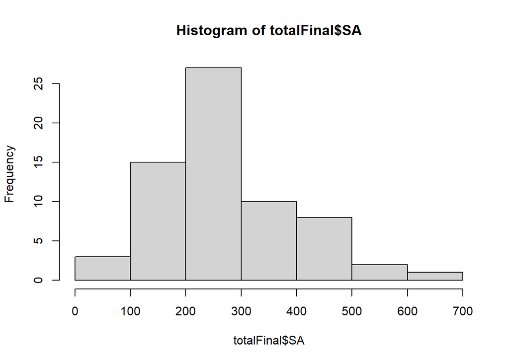

```r
#Testing normality of totalSA and totalChangeSA

hist(totalFinal$SA)
```

```r
shapiro.test(totalFinal$SA)
```

```
##
##  Shapiro-Wilk normality test
##
## data:  totalFinal$SA
## W = 0.91669, p-value = 0.0002912
```

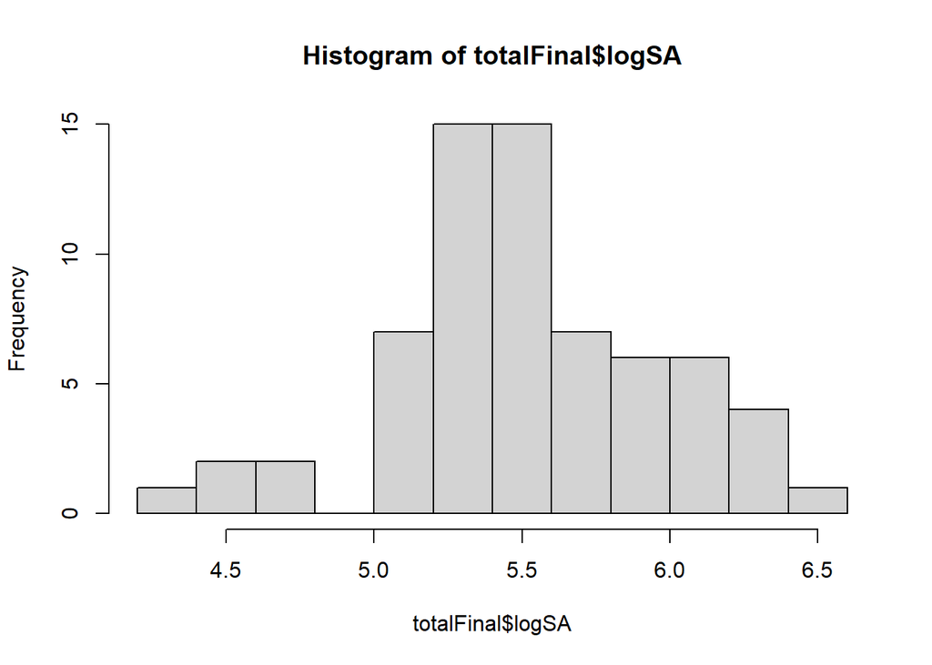

```r
#Significant so Data does not fit normal distribution
#log transform data

totalFinal$logSA <- log(totalFinal$SA)

#Re-testing normality
hist(totalFinal$logSA)
```

```r
shapiro.test(totalFinal$logSA)
```

```
##
##  Shapiro-Wilk normality test
##
## data:  totalFinal$logSA
## W = 0.96998, p-value = 0.1098
```

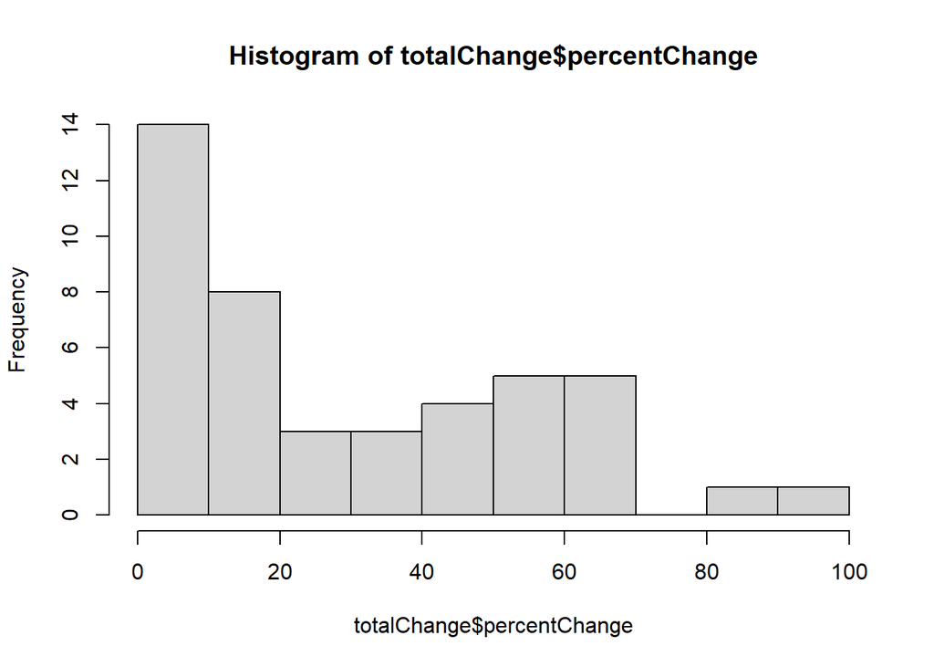

```r
#Testing normality of totalChangeSA

hist(totalChange$percentChange)
```

```r
shapiro.test(totalChange$percentChange)
```

```
##
##  Shapiro-Wilk normality test
##
## data:  totalChange$percentChange
## W = 0.8975, p-value = 0.0009124
```

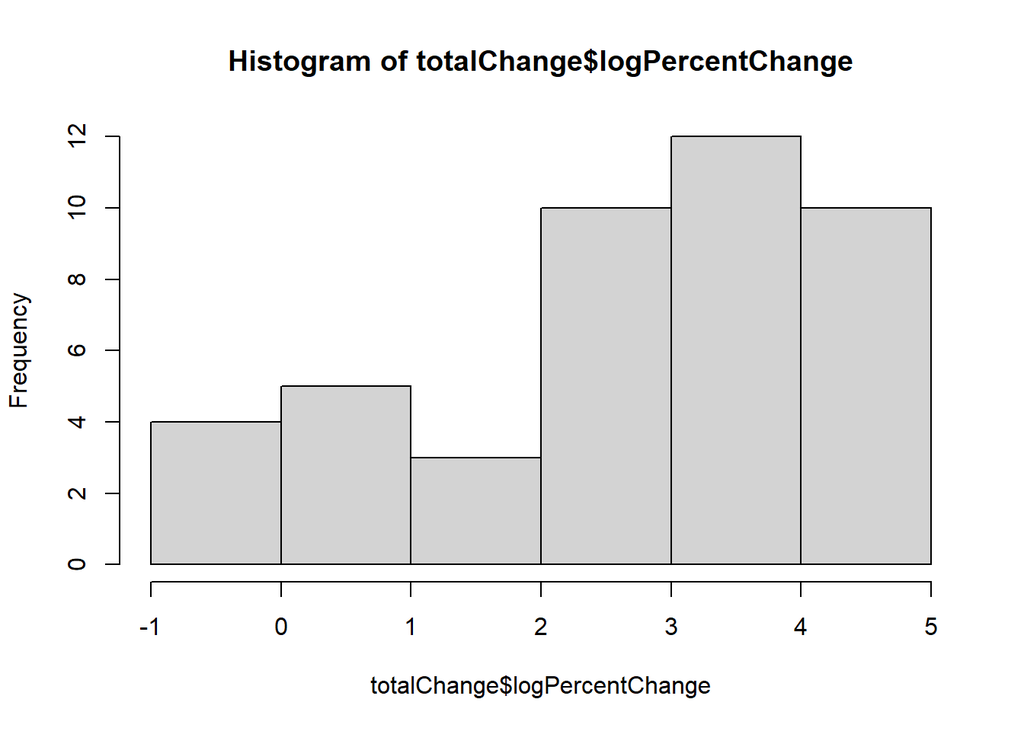

```r
#Significant so Data does not fit normal distribution
#log transform data

totalChange$logPercentChange <- log(totalChange$percentChange)

#Re-testing normality
hist(totalChange$logPercentChange)
```

```r
shapiro.test(totalChange$logPercentChange)
```

```
##
##  Shapiro-Wilk normality test
##
## data:  totalChange$logPercentChange
## W = 0.89011, p-value = 0.0005481
```

# Statistical Analyses

## With our newly formed dataset and our transformed data, we are now going to perform some Repeated Measures Analyses of variance using the `lmer()` function from the package `lme4`. We are testing our logtransformed raw SA data as well as our percent change data with **treatment** and **timepoint** as factors and **id** as a random effect.

```r
logTotalLM <- lmer(logSA ~ species*treatment*timepoint + (1 | id), totalFinal)
logTotalLManova <- anova(logTotalLM)
logTotalLManova
```

```
## Type III Analysis of Variance Table with Satterthwaite's method
##                              Sum Sq Mean Sq NumDF DenDF  F value    Pr(>F)
## species                     0.02389 0.01194     2     8   1.2734 0.3310461
## treatment                   1.91738 1.91738     1    40 204.4338 < 2.2e-16 ***
## timepoint                   2.43520 1.21760     2    40 129.8222 < 2.2e-16 ***
## species:treatment           0.18093 0.09046     2    40   9.6454 0.0003815 ***
## species:timepoint           0.04144 0.01036     4    40   1.1045 0.3677593
## treatment:timepoint         1.21613 0.60807     2    40  64.8329 2.814e-13 ***
## species:treatment:timepoint 0.04462 0.01115     4    40   1.1892 0.3303228
## ---
## Signif. codes:  0 '***' 0.001 '**' 0.01 '*' 0.05 '.' 0.1 ' ' 1
```

```r
eta_sq(logTotalLM, partial = TRUE)
```

```
## # Effect Size for ANOVA (Type III)
##
## Parameter                   | Eta2 (partial) |       95% CI
## -----------------------------------------------------------
## species                     |           0.24 | [0.00, 1.00]
## treatment                   |           0.84 | [0.76, 1.00]
## timepoint                   |           0.87 | [0.80, 1.00]
## species:treatment           |           0.33 | [0.12, 1.00]
## species:timepoint           |           0.10 | [0.00, 1.00]
## treatment:timepoint         |           0.76 | [0.65, 1.00]
## species:treatment:timepoint |           0.11 | [0.00, 1.00]
##
## - One-sided CIs: upper bound fixed at [1.00].
```

```r
r.squaredGLMM(logTotalLM)
```

```
##            R2m       R2c
## [1,] 0.5102694 0.9598659
```

```r
emmeans(logTotalLM, list(pairwise ~ timepoint), adjust = 'bonferroni')
```

```
## NOTE: Results may be misleading due to involvement in interactions
```

```
## $`emmeans of timepoint`
##  timepoint emmean    SE   df lower.CL upper.CL
##  T0          5.31 0.103 8.47     5.08     5.55
##  T3          5.58 0.103 8.47     5.35     5.82
##  T6          5.79 0.103 8.47     5.56     6.03
##
## Results are averaged over the levels of: species, treatment
## Degrees-of-freedom method: kenward-roger
## Confidence level used: 0.95
##
## $`pairwise differences of timepoint`
##  1       estimate     SE df t.ratio p.value
##  T0 - T3   -0.271 0.0301 40  -9.028  <.0001
##  T0 - T6   -0.483 0.0301 40 -16.073  <.0001
##  T3 - T6   -0.212 0.0301 40  -7.044  <.0001
##
## Results are averaged over the levels of: species, treatment
## Degrees-of-freedom method: kenward-roger
## P value adjustment: bonferroni method for 3 tests
```

```r
changeLM <- lmer(percentChange ~ species*treatment*timeSeries + (1 | id), totalChange)
```

```
## boundary (singular) fit: see help('isSingular')
```

```r
changeLManova <- anova(changeLM)
changeLManova
```

```
## Type III Analysis of Variance Table with Satterthwaite's method
##                               Sum Sq Mean Sq NumDF DenDF  F value    Pr(>F)
## species                        127.5    63.8     2    32   0.5290  0.594285
## treatment                    20730.9 20730.9     1    32 171.9868 2.039e-14 ***
## timeSeries                     918.2   918.2     1    32   7.6176  0.009485 **
## species:treatment              396.0   198.0     2    32   1.6426  0.209367
## species:timeSeries            2062.5  1031.3     2    32   8.5556  0.001056 **
## treatment:timeSeries          1123.9  1123.9     1    32   9.3238  0.004529 **
## species:treatment:timeSeries  1819.4   909.7     2    32   7.5470  0.002065 **
## ---
## Signif. codes:  0 '***' 0.001 '**' 0.01 '*' 0.05 '.' 0.1 ' ' 1
```

```r
#Treatment, timeSeries, and the interactions between species:timeSeries, treatment:timeSeries, and species:treatment:timeSeries are significant

emmeans(changeLM, list(pairwise ~ treatment), adjust = 'bonferroni')
```

```
## NOTE: Results may be misleading due to involvement in interactions
```

```
## $`emmeans of treatment`
##  treatment emmean   SE df lower.CL upper.CL
##  frag       52.33 2.41 24    47.36     57.3
##  wild        7.65 2.41 24     2.68     12.6
##
## Results are averaged over the levels of: species, timeSeries
## Degrees-of-freedom method: kenward-roger
## Confidence level used: 0.95
##
## $`pairwise differences of treatment`
##  1           estimate   SE df t.ratio p.value
##  frag - wild     44.7 3.41 24  13.114  <.0001
##
## Results are averaged over the levels of: species, timeSeries
## Degrees-of-freedom method: kenward-roger
```

```r
emmeans(changeLM, list(pairwise ~ timeSeries), adjust = 'bonferroni')
```

```
## NOTE: Results may be misleading due to involvement in interactions
```

```
## $`emmeans of timeSeries`
##  timeSeries emmean   SE df lower.CL upper.CL
##  T3-T0        34.7 2.41 24     29.7     39.7
##  T6-T3        25.3 2.41 24     20.3     30.3
##
## Results are averaged over the levels of: species, treatment
## Degrees-of-freedom method: kenward-roger
## Confidence level used: 0.95
##
## $`pairwise differences of timeSeries`
##  1                 estimate   SE df t.ratio p.value
##  (T3-T0) - (T6-T3)      9.4 3.41 24   2.760  0.0109
##
## Results are averaged over the levels of: species, treatment
## Degrees-of-freedom method: kenward-roger
```

#Here we are creating a figure for the mean percent change of each species. Included in this figure are error bars derived from the standard deviation divided by the square root of the sample size (n)

```r
se <- function(x) sqrt(var(x) / length(x))



totalChangeSe <- totalChange %>%
dplyr::select(timeSeries, treatment,species, percentChange) %>%
  dplyr::group_by(timeSeries, species, treatment) %>%
  dplyr::summarise(
    meanPC = mean(percentChange),
    sd = sd(percentChange),
    n = n(),
    se = sd/sqrt(n))
```

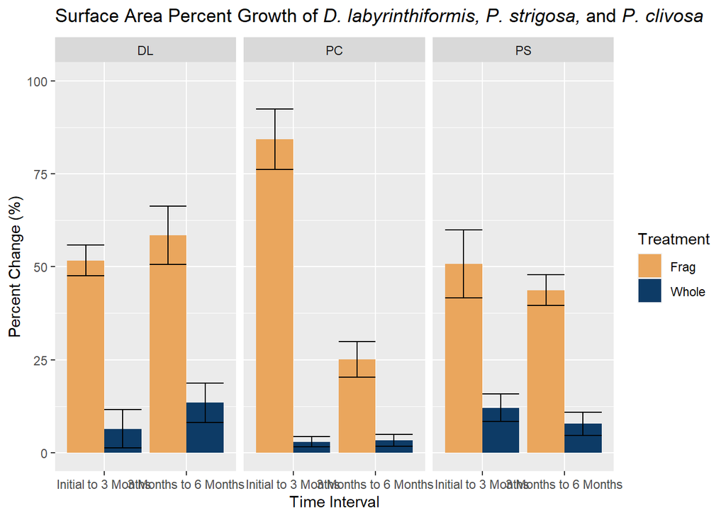

```r
SApercentChange.1 <- ggplot(totalChangeSe, aes(x = timeSeries, y = meanPC, fill = treatment)) +
  geom_bar(stat = "identity", position = position_dodge())+
  ylim(0,100)+
  facet_wrap(~species)+
  ggtitle(expression(paste("Surface Area Percent Growth of ",italic("D. labyrinthiformis, P. strigosa,")," and ",italic("P. clivosa"))))+
  scale_fill_manual(name="Treatment",values = c( "#EAA65D","#0D3B66"), labels=c('Frag', "Whole"))+
  xlab("Treatment")+
  ylab("Percent Change (%)")+
  scale_x_discrete(name = "Time Interval", labels = c("Initial to 3 Months", "3 Months to 6 Months"))+
  geom_errorbar( aes(x=timeSeries, ymin=meanPC-se, ymax=meanPC+se), position = position_dodge())
SApercentChange.1
```

[figure not shown]

```r
SApercentChange<- SApercentChange.1 + theme(
  panel.grid.major = element_line(size = 0.5, linetype = 'solid', colour = "white"),
  panel.background = element_rect(fill = '#F5F5F5'),
  plot.title = element_text(size = 35, color = 'black'),
  axis.line = element_line(colour = "black"),
  axis.ticks = element_line(color="black"),
  text = element_text(size = 35, color="black"),
  axis.text.x=element_text(size = 18, color="black"),
  axis.text.y=element_text(size = 31, color="black"),
  legend.position = "right")

SApercentChange
```

```r
ggsave("../figures/SApercentChange.png", plot = SApercentChange, height = 15, width = 20, units = 'in',dpi = 600)
```

#Here we are creating a figure for the mean T0, T3, and T6 surface area of each species. Included in this figure are error bars derived from the standard deviation divided by the square root of the sample size (n)

```r
totalSAse <- totalFinal %>%
  dplyr::select(timepoint, treatment, species, SA, logSA) %>%
  dplyr::group_by(timepoint, treatment, species) %>%
  dplyr::summarise(
    meanSA = mean(SA),
    sd = sd(SA),
    n = n(),
    se = sd/sqrt(n))
```

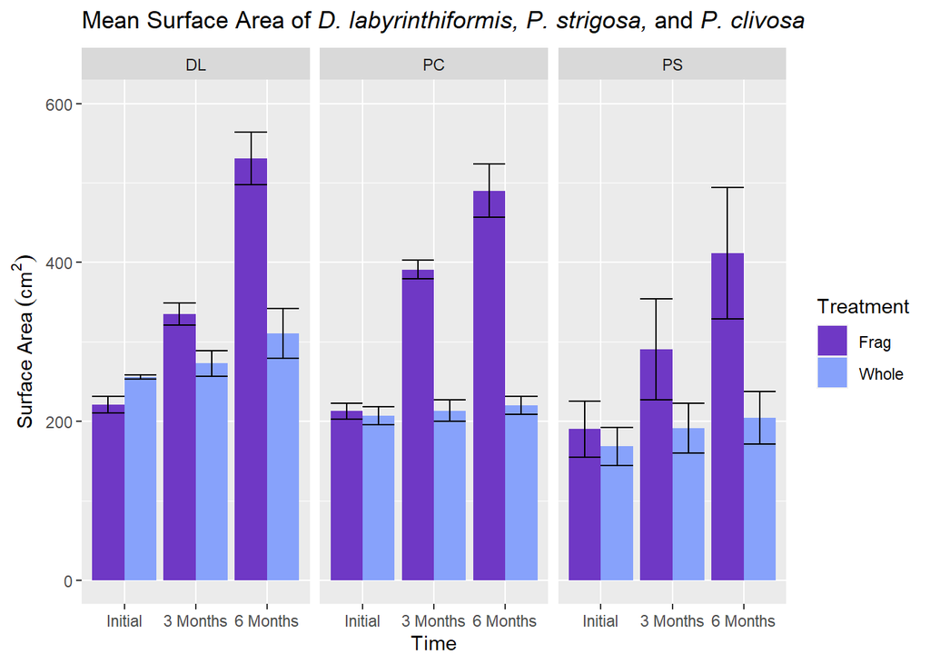

```r
SAgrowth.1 <- ggplot(data=totalSAse, aes(x = timepoint, y = meanSA, fill = treatment)) +
  geom_bar(stat = "identity", position = position_dodge())+
  ylim(0, 600)+
    facet_wrap(~species)+
  geom_errorbar( aes(x=timepoint, ymin=meanSA-se, ymax=meanSA+se), position = position_dodge())+
  scale_fill_manual(name="Treatment",values = c( "#6F38C5","#87A2FB"), labels=c('Frag', "Whole"))+
  labs(x = "Time Point", y = bquote("Surface Area" ~ (cm^2)),fill='Treatment') +
  ggtitle(expression(paste("Mean Surface Area of ",italic("D. labyrinthiformis, P. strigosa,")," and ",italic("P. clivosa"))))+
  scale_x_discrete(name = "Time", labels = c("Initial", "3 Months", "6 Months"))

SAgrowth.1
```

[figure not shown]

```r
SAgrowth <- SAgrowth.1 + theme(
  panel.grid.major = element_line(size = 0.5, linetype = 'solid', colour = "white"),
  panel.background = element_rect(fill = '#F5F5F5'),
  plot.title = element_text(size = 35, color = 'black'),
  axis.line = element_line(colour = "black"),
  axis.ticks = element_line(color="black"),
  text = element_text(size = 35, color="black"),
  axis.text.x=element_text(size = 20, color="black"),
  axis.text.y=element_text(size = 31, color="black"),
  legend.position = "right")


SAgrowth
```

```r
ggsave("../figures/SAgrowth.png", plot = SAgrowth, height = 15, width = 20, units = 'in',dpi = 600)
```